## The Evergreen State College

## Abstract

State budgets have yet to recover from the Great Recession. One key driver of state budget priorities are pension plans for public employees. This paper looks at factors exogenous to statewide pension plans to examine what may impact the funded status of a given retirement system. The sample in this study is 110 retirement systems adminstered by state governments. The exogenous factors included in the analysis are partisan control of a state’s legislature and governership, the size of state employment adjusted for the total population in the state, the number of public state employees represented by a union, the tax revenue of the state government, and the per capita GDP of the state.

## Introduction

Ongoing pension obligations strain state budgets. One way to manage the size of pension obligations is to fully fund plans, rather than defer fixed costs to a later date. This analysis will examine if significant differences exist between states in regards to the funded status of statewide pension plans, and then examine if any exogenous factors have a significant impact on plan funding within the state.

## Background

What, if any, impacts do environmental factors have on the funded status of state public employee pension plans? This study looks at factors outside of the direct control of pension plan adminstrators to examine the relationships between several risk factors and the effect that those factors have on plan funded status. The data for this study was compiled from several sources. The primary data on statewide pension plans came from the Public Plans Database at the Center for Retirement Research. Data on statewide tax revenue was compiled from Pew Charitable Trust. Partisan composition of state legislatures and governerships was obtained from the National Conference of State Legislatures. State gross domestic product per capita was from the Bureau of Economic Analysis. State employment and union participation data was Governing and the Bureau of Labor Statistics. These factors were combined into a dataset in R for purposes of this research exercise. If significant risk factors are detected, then pension plan adminsistrators can identify the risk level of their retirement environment and respond proactively to manage funding challenges.

## Data and Analysis

### Data Sources

To begin, the data was loaded from the sources listed above and combined into a single dataframe. All data is for fiscal year 2017, except for union participation which is year-end 2016.

```r
library(tidyverse)
library(reshape2)

# from https://www.pewtrusts.org/en/research-and-analysis/data-visualizations/2014/fiscal-50#ind0 , 4th quarter 2017 4 qtr rolling average
tax.data <- read_csv("../Data/TaxRevenue.csv")
#from http://www.ncsl.org/Portals/1/Documents/Elections/Legis_Control_2017_March_1_9%20am.pdf
partisan.data <- read_csv("../Data/partisanComposition.csv")
# from http://publicplansdata.org/public-plans-database/the-2018-data-update/
pension.data <- read_csv("../Data/PPD_PlanLevel.csv")
# from https://apps.bea.gov/itable/iTable.cfm?ReqID=70&step=1#reqid=70&step=1&isuri=1
gdp.data <- read_csv("../Data/percapgdp.csv")
# from http://www.governing.com/gov-data/public-workforce-salaries/states-most-government-workers-public-employees-by-job-type.html
emp.data <- read_csv("../Data/emp.data.csv")
# from http://www.governing.com/gov-data/public-workforce-salaries/union-membership-affiliation-by-state-data-statistics.html
union.data <- read_csv("../Data/uniondata.csv")


tax.data <- tax.data %>%
  select(-c(X52, X53))
tax.data <- melt(tax.data) %>%
  filter(QtrRolAvg == "2017Q4") %>% #4QtrRolAvg dollars in thousands
  rename(BudgRev = value, GovtName = variable)

pension.data <- pension.data %>%
  filter(fy == 2017) %>%
  inner_join(partisan.data, by = "GovtName") %>% #removes local govts from data set
  left_join(tax.data, by = "GovtName") %>%
  left_join(gdp.data, by = "GovtName") %>%
  left_join(emp.data, by = "GovtName") %>%
  left_join(union.data, by = "GovtName") %>%
  select(fy, PlanFullName, GovtName, PerCapGDP, ActFundedRatio_GASB, UAAL_GASB, BudgRev, LegControl, GovParty, TotMembership, state_emp_per_tenk_pop, UnionRep)

model.data <- pension.data %>%
  select(ActFundedRatio_GASB, PerCapGDP, BudgRev, state_emp_per_tenk_pop, UnionRep, LegControl, GovParty)
attach(pension.data)
```

### Analysis of Variance

In order to determine if significant differences in funding exist among states, an analysis of variance is used.

```r
state.model <- aov(ActFundedRatio_GASB ~ GovtName)
summary(state.model)
```

```
##             Df Sum Sq Mean Sq F value  Pr(>F)
## GovtName    44 1.6435 0.03735   2.102 0.00553 **
## Residuals   51 0.9064 0.01777
## ---
## Signif. codes:  0 '***' 0.001 '**' 0.01 '*' 0.05 '.' 0.1 ' ' 1
## 14 observations deleted due to missingness
```

```r
library(agricolae)
state.tukey <- HSD.test(state.model, "GovtName", group = TRUE)
state.tukey
```

```
## $statistics
##     MSerror Df      Mean       CV
##   0.0177728 51 0.7148056 18.65048
##
## $parameters
##    test   name.t ntr StudentizedRange alpha
##   Tukey GovtName  45         5.931444  0.05
##
## $means
##                ActFundedRatio_GASB          std r       Min       Max
## Alabama                  0.6835000 7.778175e-03 2 0.6780000 0.6890000
## Alaska                   0.7130000 6.505382e-02 2 0.6670000 0.7590000
## Arizona                  0.5510000 1.350111e-01 3 0.4530000 0.7050000
## Arkansas                 0.8880000 1.583919e-01 2 0.7760000 1.0000000
## California               0.6300000           NA 1 0.6300000 0.6300000
## Colorado                 0.6546667 1.219030e-01 3 0.5750000 0.7950000
## Connecticut              0.3810000           NA 1 0.3810000 0.3810000
## Delaware                 0.8650000           NA 1 0.8650000 0.8650000
## Florida                  0.8430000           NA 1 0.8430000 0.8430000
## Hawaii                   0.5490000           NA 1 0.5490000 0.5490000
## Idaho                    0.8960000           NA 1 0.8960000 0.8960000
## Illinois                 0.5323250 2.670105e-01 4 0.3540000 0.9290000
## Indiana                  0.6352696 2.188219e-01 2 0.4805391 0.7900000
## Iowa                     0.8139500 7.071068e-05 2 0.8139000 0.8140000
## Kansas                   0.6840000           NA 1 0.6840000 0.6840000
## Kentucky                 0.4143333 2.189802e-01 3 0.1630000 0.5640000
## Louisiana                0.7467300 1.463763e-01 5 0.6370000 0.9961500
## Maine                    0.8370000 3.959798e-02 2 0.8090000 0.8650000
## Maryland                 0.7147500 3.613316e-02 2 0.6892000 0.7403000
## Massachusetts            0.5840000 8.909545e-02 2 0.5210000 0.6470000
## Michigan                 0.6405000 3.464823e-02 2 0.6160000 0.6650000
## Minnesota                0.8124750 4.609515e-02 4 0.7679000 0.8523000
## Mississippi              0.6110000           NA 1 0.6110000 0.6110000
## Missouri                 0.7784800 1.520160e-01 5 0.5714000 0.9480000
## Montana                  0.7174500 1.774838e-02 2 0.7049000 0.7300000
## Nebraska                 0.8670000           NA 1 0.8670000 0.8670000
## Nevada                   0.7515000 1.767767e-02 2 0.7390000 0.7640000
## New Hampshire            0.6180000           NA 1 0.6180000 0.6180000
## New Jersey               0.5713067 1.377120e-01 3 0.4212257 0.6918594
## New Mexico               0.6890000 8.485281e-02 2 0.6290000 0.7490000
```

[output cut: 100 more lines]

```
## Vermont                  0.6282343     ab
## New Hampshire            0.6180000     ab
## Mississippi              0.6110000     ab
## South Carolina           0.5965000     ab
## Massachusetts            0.5840000     ab
## Pennsylvania             0.5785000     ab
## New Jersey               0.5713067     ab
## Arizona                  0.5510000     ab
## Hawaii                   0.5490000     ab
## Illinois                 0.5323250     ab
## Kentucky                 0.4143333     ab
## Connecticut              0.3810000     ab
##
## attr(,"class")
## [1] "group"
```

### Multiple Regression

Once the differences in the states is shown to be significant, a multiple regression can be used to analyze what, if any, exogenous factors have a significant impact on pension funding. Below are plots that look at the interactions present within the data. The following scatterplot matrix examines the relationships between the continuous terms.

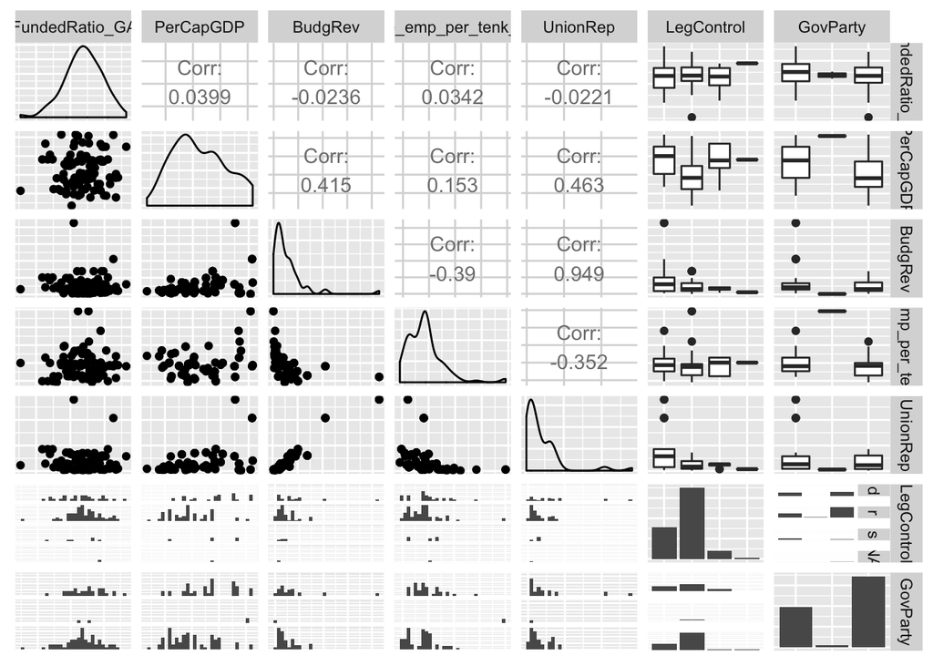

```r
library(GGally)
ggpairs(model.data) +
        theme(axis.line=element_blank(),
        axis.text=element_blank(),
        axis.ticks=element_blank())
```

Some elements do not appear to be normally distributed. However, the response variable appears normal and meets the assumptions for linear regression with levels for the categorical indicators LegControl and GovParty. Transformations can be made to Budget Revenue, State Employment, and Union Representation to improve symmetry.

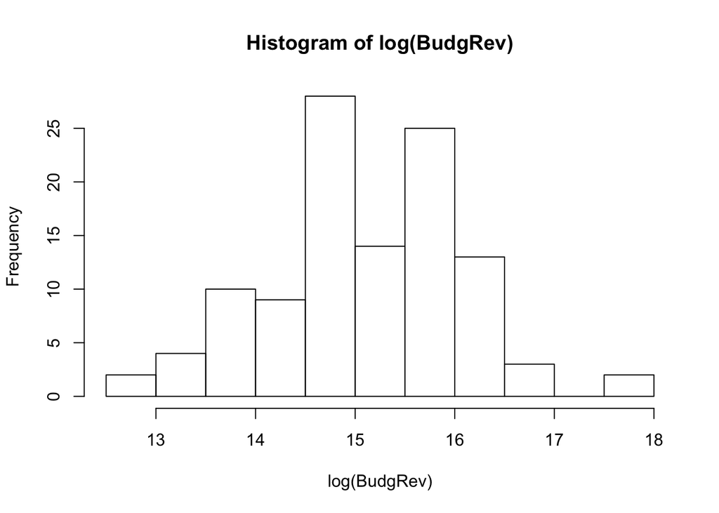

```r
hist(log(BudgRev))
```

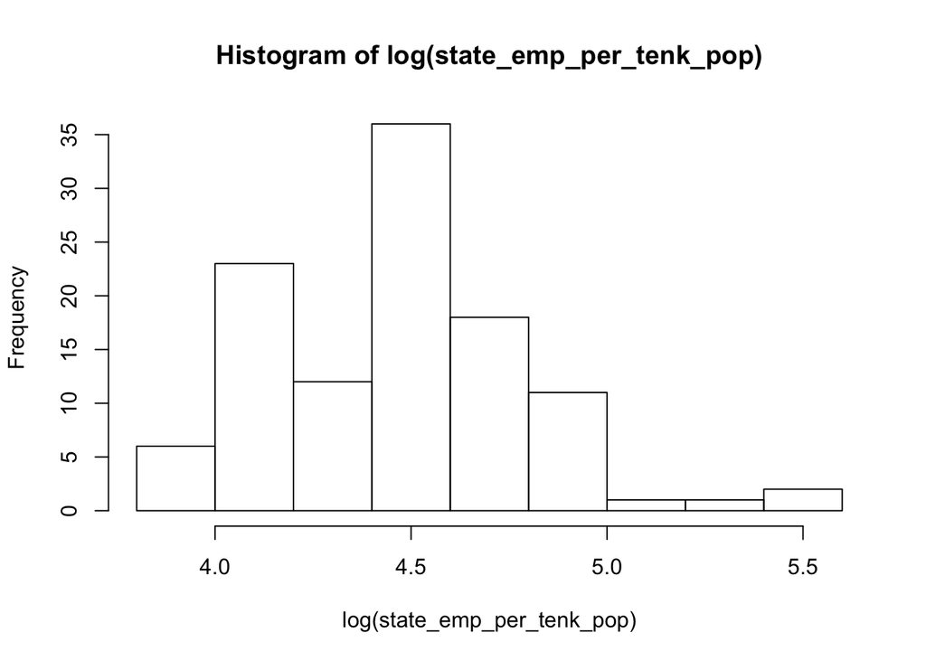

```r
hist(log(state_emp_per_tenk_pop))
```

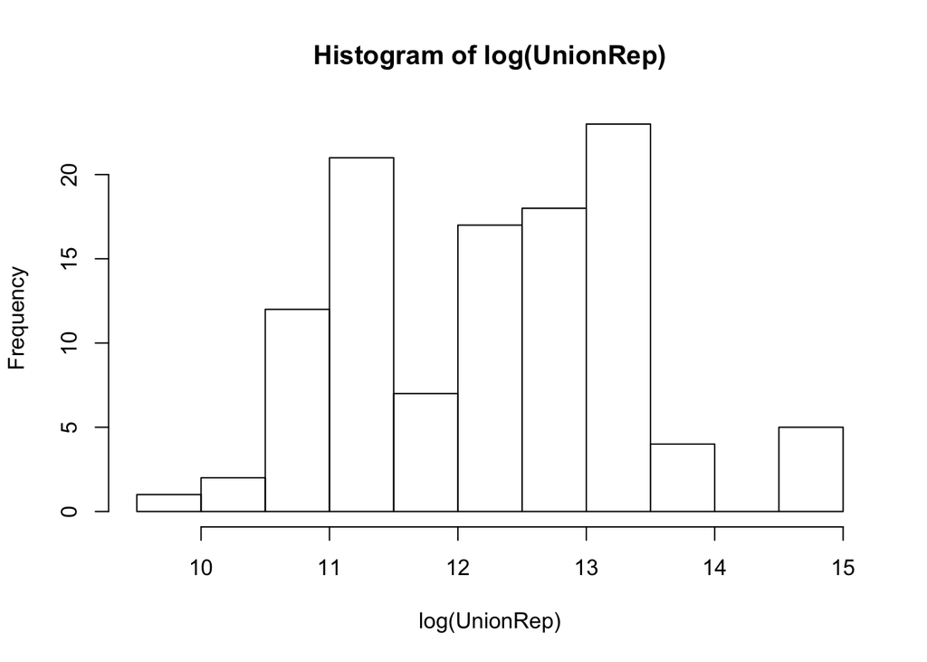

```r
hist(log(UnionRep))
```

The LM regression model is created to include the plan’s funded ratio as the response variable. A stepwise algorithm is used to determine the optimal model fit.

```r
pension.model <- lm(ActFundedRatio_GASB ~ LegControl*GovParty+log(state_emp_per_tenk_pop)*log(UnionRep)+log(BudgRev)*PerCapGDP)
summary(pension.model)
```

```
##
## Call:
## lm(formula = ActFundedRatio_GASB ~ LegControl * GovParty + log(state_emp_per_tenk_pop) *
##     log(UnionRep) + log(BudgRev) * PerCapGDP)
##
## Residuals:
##      Min       1Q   Median       3Q      Max
## -0.51648 -0.09361 -0.00443  0.09553  0.32081
##
## Coefficients: (2 not defined because of singularities)
##                                             Estimate Std. Error t value
## (Intercept)                                5.872e+00  3.845e+00   1.527
## LegControlr                               -4.419e-02  7.467e-02  -0.592
## LegControls                               -2.418e-01  1.018e-01  -2.376
## GovPartyi                                  8.507e-02  1.933e-01   0.440
## GovPartyr                                 -1.821e-01  6.675e-02  -2.728
## log(state_emp_per_tenk_pop)               -5.469e-01  7.054e-01  -0.775
## log(UnionRep)                             -2.077e-01  2.636e-01  -0.788
## log(BudgRev)                              -1.601e-01  1.661e-01  -0.964
## PerCapGDP                                 -4.000e-05  4.002e-05  -0.999
## LegControlr:GovPartyi                             NA         NA      NA
## LegControls:GovPartyi                             NA         NA      NA
## LegControlr:GovPartyr                      1.737e-01  8.044e-02   2.159
## LegControls:GovPartyr                      4.548e-01  1.604e-01   2.836
## log(state_emp_per_tenk_pop):log(UnionRep)  3.811e-02  5.624e-02   0.678
## log(BudgRev):PerCapGDP                     2.948e-06  2.732e-06   1.079
##                                           Pr(>|t|)
## (Intercept)                                0.13057
## LegControlr                                0.55563
## LegControls                                0.01986 *
## GovPartyi                                  0.66100
## GovPartyr                                  0.00780 **
## log(state_emp_per_tenk_pop)                0.44041
## log(UnionRep)                              0.43295
## log(BudgRev)                               0.33799
## PerCapGDP                                  0.32053
## LegControlr:GovPartyi                           NA
## LegControls:GovPartyi                           NA
## LegControlr:GovPartyr                      0.03376 *
## LegControls:GovPartyr                      0.00576 **
## log(state_emp_per_tenk_pop):log(UnionRep)  0.49987
## log(BudgRev):PerCapGDP                     0.28367
## ---
## Signif. codes:  0 '***' 0.001 '**' 0.01 '*' 0.05 '.' 0.1 ' ' 1
##
## Residual standard error: 0.1597 on 82 degrees of freedom
##   (15 observations deleted due to missingness)
## Multiple R-squared:  0.1725, Adjusted R-squared:  0.05145
## F-statistic: 1.425 on 12 and 82 DF,  p-value: 0.1715
```

```r
model1 <- step(pension.model)
```

```
## Start:  AIC=-336.56
## ActFundedRatio_GASB ~ LegControl * GovParty + log(state_emp_per_tenk_pop) *
##     log(UnionRep) + log(BudgRev) * PerCapGDP
##
##                                             Df Sum of Sq    RSS     AIC
## - log(state_emp_per_tenk_pop):log(UnionRep)  1  0.011709 2.1023 -338.03
## - log(BudgRev):PerCapGDP                     1  0.029693 2.1203 -337.22
## <none>                                                   2.0906 -336.56
## - LegControl:GovParty                        2  0.254675 2.3453 -329.64
##
## Step:  AIC=-338.03
## ActFundedRatio_GASB ~ LegControl + GovParty + log(state_emp_per_tenk_pop) +
##     log(UnionRep) + log(BudgRev) + PerCapGDP + LegControl:GovParty +
##     log(BudgRev):PerCapGDP
##
##                               Df Sum of Sq    RSS     AIC
## - log(UnionRep)                1  0.011576 2.1139 -339.51
## - log(state_emp_per_tenk_pop)  1  0.016637 2.1189 -339.28
## - log(BudgRev):PerCapGDP       1  0.035437 2.1377 -338.44
## <none>                                     2.1023 -338.03
## - LegControl:GovParty          2  0.250667 2.3530 -331.33
##
## Step:  AIC=-339.51
## ActFundedRatio_GASB ~ LegControl + GovParty + log(state_emp_per_tenk_pop) +
##     log(BudgRev) + PerCapGDP + LegControl:GovParty + log(BudgRev):PerCapGDP
##
##                               Df Sum of Sq    RSS     AIC
## - log(state_emp_per_tenk_pop)  1  0.010004 2.1239 -341.06
## - log(BudgRev):PerCapGDP       1  0.032450 2.1463 -340.06
## <none>                                     2.1139 -339.51
## - LegControl:GovParty          2  0.239312 2.3532 -333.32
##
## Step:  AIC=-341.06
## ActFundedRatio_GASB ~ LegControl + GovParty + log(BudgRev) +
##     PerCapGDP + LegControl:GovParty + log(BudgRev):PerCapGDP
##
##                          Df Sum of Sq    RSS     AIC
## - log(BudgRev):PerCapGDP  1  0.026297 2.1502 -341.89
## <none>                                2.1239 -341.06
## - LegControl:GovParty     2  0.231823 2.3557 -335.22
```

[output cut: 10 more lines]

```
##
## Step:  AIC=-343.74
## ActFundedRatio_GASB ~ LegControl + GovParty + PerCapGDP + LegControl:GovParty
##
##                       Df Sum of Sq    RSS     AIC
## - PerCapGDP            1  0.023007 2.1766 -344.73
## <none>                             2.1536 -343.74
## - LegControl:GovParty  2  0.260576 2.4141 -336.89
##
## Step:  AIC=-344.73
## ActFundedRatio_GASB ~ LegControl + GovParty + LegControl:GovParty
##
##                       Df Sum of Sq    RSS     AIC
## <none>                             2.1766 -344.73
## - LegControl:GovParty  2   0.24498 2.4215 -338.60
```

```r
summary(model1)
```

```
##
## Call:
## lm(formula = ActFundedRatio_GASB ~ LegControl + GovParty + LegControl:GovParty)
##
## Residuals:
##      Min       1Q   Median       3Q      Max
## -0.55628 -0.09498 -0.01125  0.09912  0.30675
##
## Coefficients: (2 not defined because of singularities)
##                       Estimate Std. Error t value Pr(>|t|)
## (Intercept)            0.80649    0.04742  17.008  < 2e-16 ***
## LegControlr           -0.06081    0.06160  -0.987  0.32626
## LegControls           -0.22024    0.09183  -2.398  0.01858 *
## GovPartyi             -0.03268    0.11795  -0.277  0.78240
## GovPartyr             -0.18424    0.06086  -3.027  0.00323 **
## LegControlr:GovPartyi       NA         NA      NA       NA
## LegControls:GovPartyi       NA         NA      NA       NA
## LegControlr:GovPartyr  0.15784    0.07632   2.068  0.04156 *
## LegControls:GovPartyr  0.43499    0.14918   2.916  0.00450 **
## ---
## Signif. codes:  0 '***' 0.001 '**' 0.01 '*' 0.05 '.' 0.1 ' ' 1
##
## Residual standard error: 0.1573 on 88 degrees of freedom
##   (15 observations deleted due to missingness)
## Multiple R-squared:  0.1385, Adjusted R-squared:  0.07977
## F-statistic: 2.358 on 6 and 88 DF,  p-value: 0.03694
```